# Latihan MPDW

Reynd Hamonangan Pasaribu

2023-09-21

## White Noise

Pembangkitan data berpola AR, MA, ARMA, dan banyak proses deret waktu lainnya diawali pembangkitan *white noise*. *White noise* merupakan sederet nilai dari peubah bebas stokastik identik. Oleh karena itu, *white noise* memiliki dua karakteristik penting:

1. *White noise* tidak memiliki autokorelasi (**karena saling bebas**)
2. Nilai harapan dan ragam *white noise* sama (**karena berasal dari peubah acak bebas stokastik identik**)

*White noise* dibangkitkan dari suatu peubah acak, umumnya peubah acak normal.

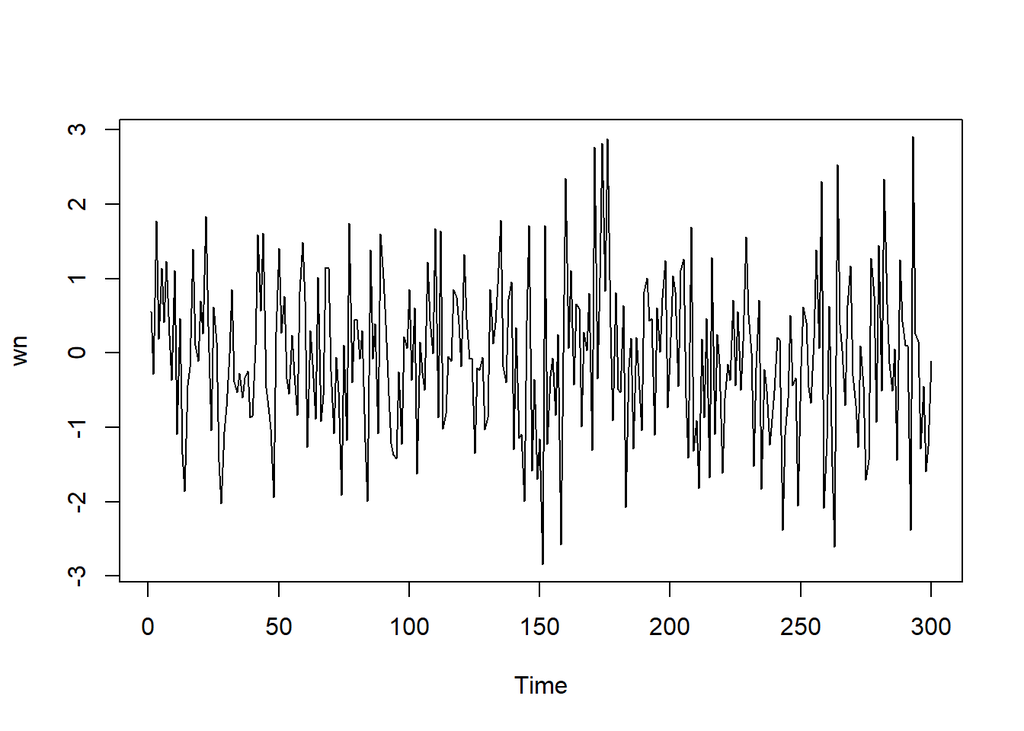

```r
set.seed(013)
wn <- rnorm(300)
ts.plot(wn)
```

Dapat terlihat bahwa *white noise* tidak memiliki autokorelasi dari ACF. Perhatikan bahwa lag ke-0 adalah korelasi observasi ke-t dengan dirinya sendiri. Nilai korelasi tersebut pasti 1. Sebagai alternatif, lag pertama di plot ACF dapat ditetapkan sebagai 1 (alih-alih 0) dengan menambahkan argumen `xlim(1, lag akhir)`. Plot tersebut dapat disandingkan bersamaan dengan membuat matriks $1 \times 2$ dengan `par(mfrow = c(1,2))`.

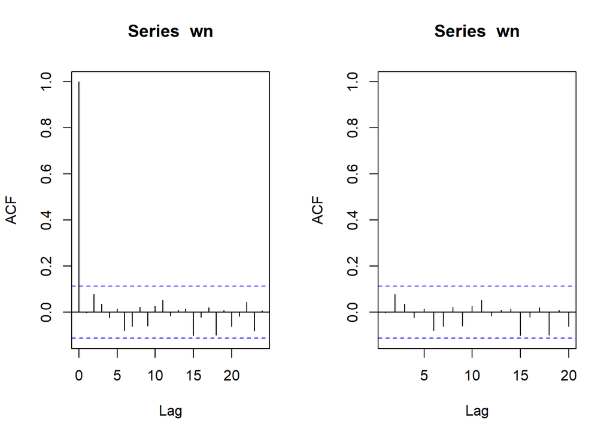

```r
par(mfrow = c(1, 2))
acf(wn)
acf(wn, xlim = c(1, 20))
```

## Proses MA

Proses MA dapat dituliskan sebagai berikut:

$$y_{t} = c + e_t + \theta_{1}e_{t-1} + \theta_{2}e_{t-2} + \dots +
\theta_{q}e_{t-q} = c+{e_t+\sum_{i=1}^p \theta_ie_{t-i}}$$
Terlihat bahwa $e_t$, atau *white noise*, berperan penting dalam pembangkitan proses MA.

## Pembangkitan Proses MA(2)

Akan dicoba membangkitkan proses MA paling sederhana, yaitu MA(2) dengan $\theta_1 = 0.4$ dan $\theta_ = 0.6$ sebanyak 300 observasi dan $c=0$.

```r
set.seed(013)
ma <- wn[c(1,2)]
```

$$y_t =
e_t+0.4e_{t-1}+0.6e_{t-2}$$

```r
for(i in 3:300){
   ma[i] <- wn[i] + 0.4 * wn[i - 1]+ 0.6 * wn[i - 2]
}
ma
```

```
##   [1]  0.554326939 -0.280271940  1.995650757  0.729222306  2.282552217
##   [6]  0.984928665  2.081232697  0.977797975  0.466993029  1.100998966
##  [11] -0.870765927  0.687519883 -1.832392552 -2.123298422 -1.998856990
##  [16] -1.483505357  1.054939508  0.542867711  0.763685396  0.716847653
##  [21]  0.474769477  2.362515508  1.249393342  0.199248822  0.416461528
##  [26] -0.229817896 -1.027464566 -2.521157825 -2.743365393 -2.367153100
##  [31] -0.933642813  0.407626878 -0.049298947 -0.171229683 -0.713925464
##  [36] -1.030938897 -0.739099525 -0.738129431 -1.159110801 -1.337003439
##  [41] -0.756113195  1.121987214  1.262712494  2.795097560  0.517038564
##  [46]  0.055126232 -1.594969658 -2.782811968 -1.111982323  0.356523266
##  [51]  1.002759029  1.709788945  0.117069130 -0.232483082 -0.193525355
##  [56] -0.531797880 -0.818990225  0.311622970  1.310009694  1.789058347
##  [61] -0.091489156  0.213447468 -0.785442899 -0.769082130  0.568812661
##  [66] -1.048652139 -0.334265022  0.368492633  1.259634053  0.908306353
##  [71] -0.496284517 -0.639833503 -1.193357428 -2.151220818 -0.965931401
```

[output cut: 45 more lines]

Selain menggunakan cara di atas, pembangkitan proses MA(2) dapat dilakukan dengan fungsi `arima.sim()` sebagai berikut.

```r
ma1 <- arima.sim(list(order=c(0,0,2), ma=c(0.4,0.6)), n=300)
ma1
```

```
## Time Series:
## Start = 1
## End = 300
## Frequency = 1
##   [1]  1.995650757  0.729222306  2.282552217  0.984928665  2.081232697
##   [6]  0.977797975  0.466993029  1.100998966 -0.870765927  0.687519883
##  [11] -1.832392552 -2.123298422 -1.998856990 -1.483505357  1.054939508
##  [16]  0.542867711  0.763685396  0.716847653  0.474769477  2.362515508
##  [21]  1.249393342  0.199248822  0.416461528 -0.229817896 -1.027464566
##  [26] -2.521157825 -2.743365393 -2.367153100 -0.933642813  0.407626878
##  [31] -0.049298947 -0.171229683 -0.713925464 -1.030938897 -0.739099525
##  [36] -0.738129431 -1.159110801 -1.337003439 -0.756113195  1.121987214
##  [41]  1.262712494  2.795097560  0.517038564  0.055126232 -1.594969658
##  [46] -2.782811968 -1.111982323  0.356523266  1.002759029  1.709788945
##  [51]  0.117069130 -0.232483082 -0.193525355 -0.531797880 -0.818990225
```

[output cut: 49 more lines]

### Plot Time Series

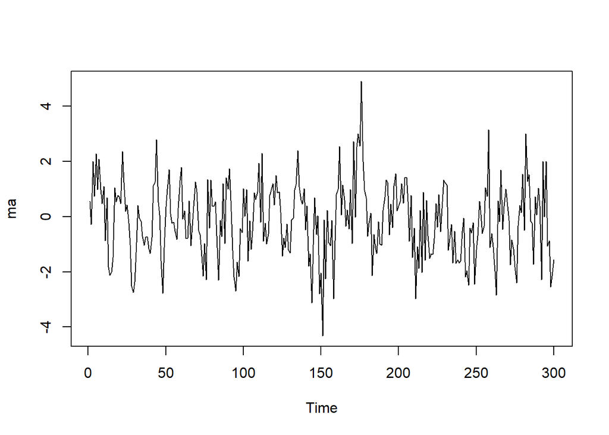

```r
ts.plot(ma)
```

Berdasarkan plot time series, terlihat bahwa data MA(2) yang dibangkitkan stasioner dalam rataan

### Plot ACF

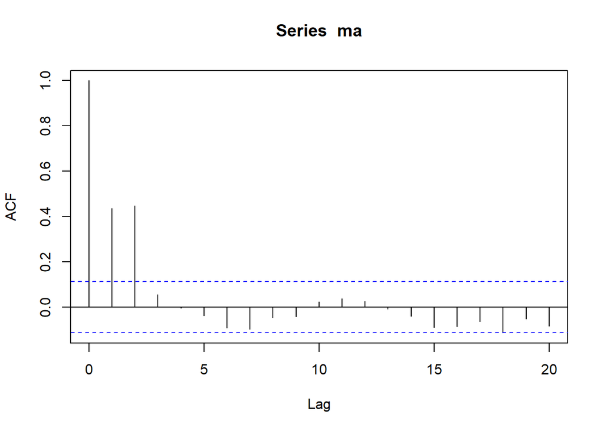

```r
acf(ma,lag.max = 20)
```

### Plot PACF

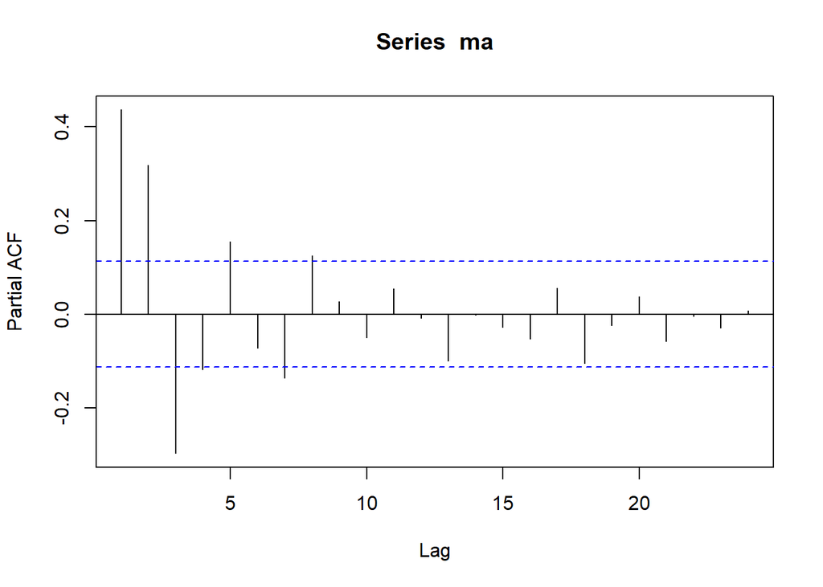

```r
pacf(ma)
```

Berdasarkan plot PACF tersebut, terlihat bahwa plot PACF cenderung *tails off* dan membentuk gelombang sinus

### Plot EACF

```r
TSA::eacf(ma)
```

```
## AR/MA
##   0 1 2 3 4 5 6 7 8 9 10 11 12 13
## 0 x x o o o o o o o o o  o  o  o
## 1 x x o o o o o o o o o  o  o  o
## 2 x x x o o o o o o o o  o  o  o
## 3 x x x o x o o o o o o  o  o  o
## 4 x x x x o x o o o o o  o  o  o
## 5 x x x o x x x o o o o  o  o  o
## 6 x x x o x x o x o o o  o  o  o
## 7 x x x x x x o x o o o  o  o  o
```

Berdasarkan pola segitiga nol pada plot EACF, terlihat bahwa segitiga nol berada pada ordo AR(0) dan ordo MA(2)

### Scatterplot Antar Lag

#### Korelasi antara $Y_t$ dengan $Y_{t-1}$

```r
#Yt
yt_ma1 <- ma[-1]
yt_ma1
```

```
##   [1] -0.280271940  1.995650757  0.729222306  2.282552217  0.984928665
##   [6]  2.081232697  0.977797975  0.466993029  1.100998966 -0.870765927
##  [11]  0.687519883 -1.832392552 -2.123298422 -1.998856990 -1.483505357
##  [16]  1.054939508  0.542867711  0.763685396  0.716847653  0.474769477
##  [21]  2.362515508  1.249393342  0.199248822  0.416461528 -0.229817896
##  [26] -1.027464566 -2.521157825 -2.743365393 -2.367153100 -0.933642813
##  [31]  0.407626878 -0.049298947 -0.171229683 -0.713925464 -1.030938897
##  [36] -0.739099525 -0.738129431 -1.159110801 -1.337003439 -0.756113195
##  [41]  1.121987214  1.262712494  2.795097560  0.517038564  0.055126232
##  [46] -1.594969658 -2.782811968 -1.111982323  0.356523266  1.002759029
##  [51]  1.709788945  0.117069130 -0.232483082 -0.193525355 -0.531797880
##  [56] -0.818990225  0.311622970  1.310009694  1.789058347 -0.091489156
##  [61]  0.213447468 -0.785442899 -0.769082130  0.568812661 -1.048652139
##  [66] -0.334265022  0.368492633  1.259634053  0.908306353 -0.496284517
##  [71] -0.639833503 -1.193357428 -2.151220818 -0.965931401 -2.279116808
```

[output cut: 45 more lines]

```r
#Yt-1
yt_1_ma <- ma[-300]
yt_1_ma
```

```
##   [1]  0.554326939 -0.280271940  1.995650757  0.729222306  2.282552217
##   [6]  0.984928665  2.081232697  0.977797975  0.466993029  1.100998966
##  [11] -0.870765927  0.687519883 -1.832392552 -2.123298422 -1.998856990
##  [16] -1.483505357  1.054939508  0.542867711  0.763685396  0.716847653
##  [21]  0.474769477  2.362515508  1.249393342  0.199248822  0.416461528
##  [26] -0.229817896 -1.027464566 -2.521157825 -2.743365393 -2.367153100
##  [31] -0.933642813  0.407626878 -0.049298947 -0.171229683 -0.713925464
##  [36] -1.030938897 -0.739099525 -0.738129431 -1.159110801 -1.337003439
##  [41] -0.756113195  1.121987214  1.262712494  2.795097560  0.517038564
##  [46]  0.055126232 -1.594969658 -2.782811968 -1.111982323  0.356523266
##  [51]  1.002759029  1.709788945  0.117069130 -0.232483082 -0.193525355
##  [56] -0.531797880 -0.818990225  0.311622970  1.310009694  1.789058347
##  [61] -0.091489156  0.213447468 -0.785442899 -0.769082130  0.568812661
##  [66] -1.048652139 -0.334265022  0.368492633  1.259634053  0.908306353
##  [71] -0.496284517 -0.639833503 -1.193357428 -2.151220818 -0.965931401
```

[output cut: 45 more lines]

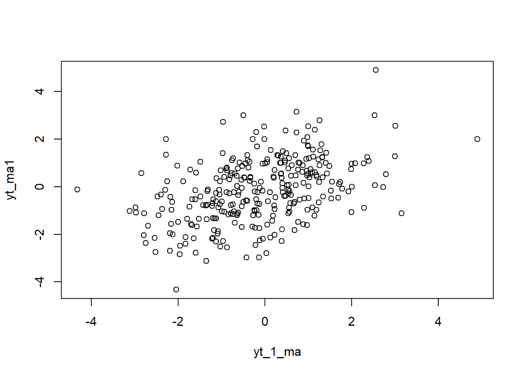

```r
plot(y=yt_ma1,x=yt_1_ma)
```

Berdasarkan scatterplot tersebut, terlihat bahwa terdapat hubungan positif antara $Y_t$ dengan $Y_{t-1}$. Hal ini sesuai dengan teori yang ada

```r
cor(yt_ma1,yt_1_ma)
```

```
## [1] 0.4376403
```

#### Korelasi antara $Y_t$ dengan $Y_{t-2}$

```r
#Yt
yt_ma2 <- ma[c(-1,-2)]
yt_ma2
```

```
##   [1]  1.995650757  0.729222306  2.282552217  0.984928665  2.081232697
##   [6]  0.977797975  0.466993029  1.100998966 -0.870765927  0.687519883
##  [11] -1.832392552 -2.123298422 -1.998856990 -1.483505357  1.054939508
##  [16]  0.542867711  0.763685396  0.716847653  0.474769477  2.362515508
##  [21]  1.249393342  0.199248822  0.416461528 -0.229817896 -1.027464566
##  [26] -2.521157825 -2.743365393 -2.367153100 -0.933642813  0.407626878
##  [31] -0.049298947 -0.171229683 -0.713925464 -1.030938897 -0.739099525
##  [36] -0.738129431 -1.159110801 -1.337003439 -0.756113195  1.121987214
##  [41]  1.262712494  2.795097560  0.517038564  0.055126232 -1.594969658
##  [46] -2.782811968 -1.111982323  0.356523266  1.002759029  1.709788945
##  [51]  0.117069130 -0.232483082 -0.193525355 -0.531797880 -0.818990225
##  [56]  0.311622970  1.310009694  1.789058347 -0.091489156  0.213447468
##  [61] -0.785442899 -0.769082130  0.568812661 -1.048652139 -0.334265022
##  [66]  0.368492633  1.259634053  0.908306353 -0.496284517 -0.639833503
##  [71] -1.193357428 -2.151220818 -0.965931401 -2.279116808  1.338770726
```

[output cut: 45 more lines]

```r
#Yt-1
yt_2_ma <- ma[c(-299,-300)]
yt_2_ma
```

```
##   [1]  0.554326939 -0.280271940  1.995650757  0.729222306  2.282552217
##   [6]  0.984928665  2.081232697  0.977797975  0.466993029  1.100998966
##  [11] -0.870765927  0.687519883 -1.832392552 -2.123298422 -1.998856990
##  [16] -1.483505357  1.054939508  0.542867711  0.763685396  0.716847653
##  [21]  0.474769477  2.362515508  1.249393342  0.199248822  0.416461528
##  [26] -0.229817896 -1.027464566 -2.521157825 -2.743365393 -2.367153100
##  [31] -0.933642813  0.407626878 -0.049298947 -0.171229683 -0.713925464
##  [36] -1.030938897 -0.739099525 -0.738129431 -1.159110801 -1.337003439
##  [41] -0.756113195  1.121987214  1.262712494  2.795097560  0.517038564
##  [46]  0.055126232 -1.594969658 -2.782811968 -1.111982323  0.356523266
##  [51]  1.002759029  1.709788945  0.117069130 -0.232483082 -0.193525355
##  [56] -0.531797880 -0.818990225  0.311622970  1.310009694  1.789058347
##  [61] -0.091489156  0.213447468 -0.785442899 -0.769082130  0.568812661
##  [66] -1.048652139 -0.334265022  0.368492633  1.259634053  0.908306353
##  [71] -0.496284517 -0.639833503 -1.193357428 -2.151220818 -0.965931401
```

[output cut: 45 more lines]

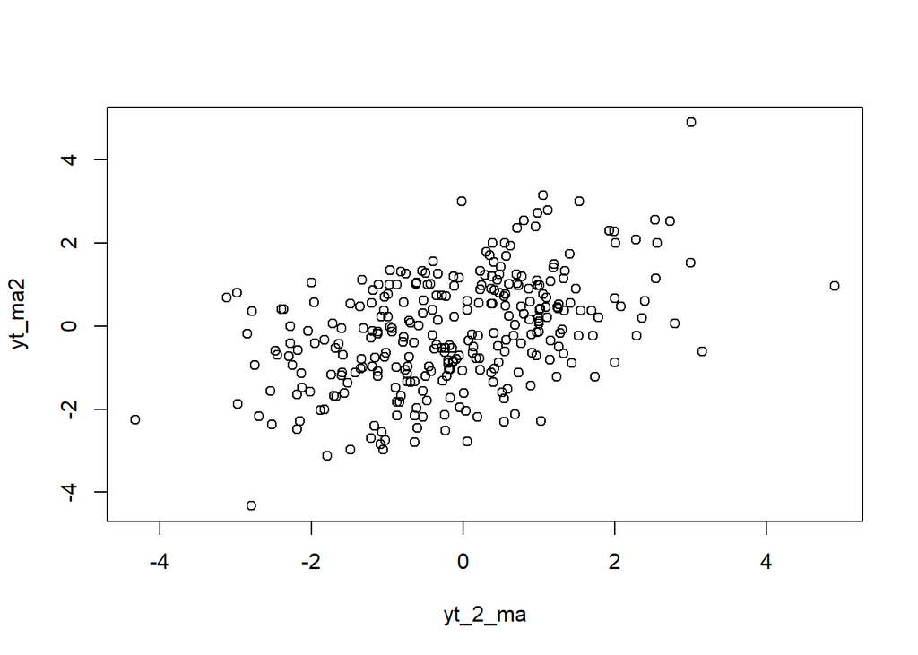

```r
plot(y=yt_ma2,x=yt_2_ma)
```

Berdasarkan scatterplot tersebut, terlihat bahwa terdapat hubungan positif antara $Y_t$ dengan $Y_{t-2}$. Hal ini sesuai dengan teori yang ada

```r
cor(yt_ma2,yt_2_ma)
```

```
## [1] 0.4508875
```

#### Korelasi antara $Y_t$ dengan $Y_{t-3}$

```r
#Yt
yt_ma3 <- ma[c(-1,-2,-3)]
yt_ma3
```

```
##   [1]  0.729222306  2.282552217  0.984928665  2.081232697  0.977797975
##   [6]  0.466993029  1.100998966 -0.870765927  0.687519883 -1.832392552
##  [11] -2.123298422 -1.998856990 -1.483505357  1.054939508  0.542867711
##  [16]  0.763685396  0.716847653  0.474769477  2.362515508  1.249393342
##  [21]  0.199248822  0.416461528 -0.229817896 -1.027464566 -2.521157825
##  [26] -2.743365393 -2.367153100 -0.933642813  0.407626878 -0.049298947
##  [31] -0.171229683 -0.713925464 -1.030938897 -0.739099525 -0.738129431
##  [36] -1.159110801 -1.337003439 -0.756113195  1.121987214  1.262712494
##  [41]  2.795097560  0.517038564  0.055126232 -1.594969658 -2.782811968
##  [46] -1.111982323  0.356523266  1.002759029  1.709788945  0.117069130
##  [51] -0.232483082 -0.193525355 -0.531797880 -0.818990225  0.311622970
##  [56]  1.310009694  1.789058347 -0.091489156  0.213447468 -0.785442899
##  [61] -0.769082130  0.568812661 -1.048652139 -0.334265022  0.368492633
##  [66]  1.259634053  0.908306353 -0.496284517 -0.639833503 -1.193357428
##  [71] -2.151220818 -0.965931401 -2.279116808  1.338770726 -0.406952874
```

[output cut: 45 more lines]

```r
#Yt-1
yt_3_ma <- ma[c(-298,-299,-300)]
yt_3_ma
```

```
##   [1]  0.554326939 -0.280271940  1.995650757  0.729222306  2.282552217
##   [6]  0.984928665  2.081232697  0.977797975  0.466993029  1.100998966
##  [11] -0.870765927  0.687519883 -1.832392552 -2.123298422 -1.998856990
##  [16] -1.483505357  1.054939508  0.542867711  0.763685396  0.716847653
##  [21]  0.474769477  2.362515508  1.249393342  0.199248822  0.416461528
##  [26] -0.229817896 -1.027464566 -2.521157825 -2.743365393 -2.367153100
##  [31] -0.933642813  0.407626878 -0.049298947 -0.171229683 -0.713925464
##  [36] -1.030938897 -0.739099525 -0.738129431 -1.159110801 -1.337003439
##  [41] -0.756113195  1.121987214  1.262712494  2.795097560  0.517038564
##  [46]  0.055126232 -1.594969658 -2.782811968 -1.111982323  0.356523266
##  [51]  1.002759029  1.709788945  0.117069130 -0.232483082 -0.193525355
##  [56] -0.531797880 -0.818990225  0.311622970  1.310009694  1.789058347
##  [61] -0.091489156  0.213447468 -0.785442899 -0.769082130  0.568812661
##  [66] -1.048652139 -0.334265022  0.368492633  1.259634053  0.908306353
##  [71] -0.496284517 -0.639833503 -1.193357428 -2.151220818 -0.965931401
```

[output cut: 45 more lines]

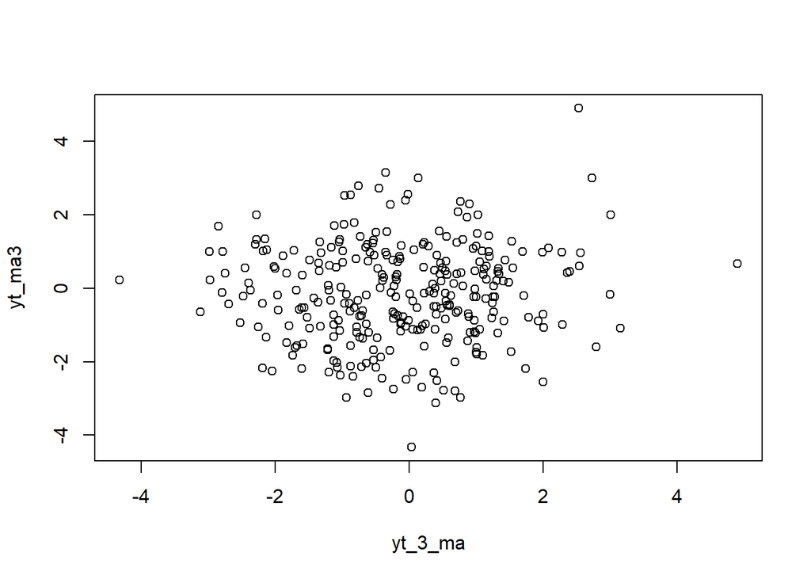

```r
plot(y=yt_ma3,x=yt_3_ma)
```

```r
cor(yt_ma3,yt_3_ma)
```

```
## [1] 0.05700051
```

## Proses AR

Proses AR dapat dituliskan sebagai berikut:

$$y_{t} = c + e_t + \phi_{1}Y_{t-1} +
\phi_{2}Y_{t-2} + \dots + \phi_{q}Y_{t-q} = c+{e_t+\sum_{i=1}^p
\phi_iY_{t-i}}$$
Terlihat bahwa $Y_t$ berperan penting dalam pembangkitan proses AR.

## Pembangkitan Proses AR

```r
set.seed(013)
```

$$Y_t = e_t+0.5Y_{t-1}++0.2Y_{t-2}$$

```r
n<-length(wn)
n
```

```
## [1] 300
```

```r
ar <- c(1:n)
for (i in 3:n) {ar[i]<-wn[i]+0.5*ar[i-1]+0.2*ar[i-2]}
ar
```

```
##   [1]  1.0000000000  2.0000000000  2.9751633696  2.0749018065  2.7750097236
##   [6]  2.2180113566  2.8935141789  2.1270390330  1.2768395791  2.1689718684
##  [11]  0.2462598784  1.0187952211 -0.8023349463 -2.0534355833 -1.6270401901
##  [16] -1.4181541123  0.3619464195 -0.0019943670 -0.0430467096  0.6803030017
##  [21]  0.5940848299  2.2692663171  1.6108525434  0.2138694086  1.0492893403
##  [26]  0.7167730812 -0.8910724453 -2.3292254072 -2.3997849529 -2.3938812737
##  [31] -1.6851082975 -0.4735330278 -0.9572796691 -1.0998579504 -1.0146108718
##  [36] -1.3330186313 -1.2022987955 -1.1092906695 -1.6578804931 -1.8977691329
##  [41] -1.1801203200  0.6204195404  0.6406805823  2.0589036930  0.6889378038
##  [46]  0.0301482399 -0.8704773211 -2.3670245392 -1.0804604446  0.3947185365
##  [51]  0.2543963686  0.9616669605  0.1826943426 -0.2625101956  0.1396457657
##  [56] -0.2805073785 -0.9528006689  0.2940085459  1.4401353703  1.4785450357
##  [61] -0.2342745592  0.4768434712  0.0437597178 -0.7716737805  0.6359809117
##  [66] -0.7568693828 -0.8251330133  0.5864251014  1.2720105101  0.5138475126
##  [71] -0.5754762910 -0.2464156282 -0.7550004167 -2.3344570229 -1.2110721135
```

[output cut: 45 more lines]

Selain menggunakan cara di atas, pembangkitan proses AR dapat dilakukan dengan fungsi `arima.sim()` sebagai berikut.

```r
ar1 <- arima.sim(list(order=c(2,0,0), ar=c(0.5,0.2)), n=300)
ar1
```

```
## Time Series:
## Start = 1
## End = 300
## Frequency = 1
##   [1]  0.7144311596 -0.8928578035 -2.3305864706 -2.4008225562 -2.3946722881
##   [6] -1.6857113253 -0.4739927446 -0.9576301330 -1.1001251257 -1.0148145523
##  [11] -1.3331739066 -1.2024171692 -1.1093809115 -1.6579492888 -1.8978215791
##  [16] -1.1801603022  0.6203890600  0.6406573457  2.0588859786  0.6889242992
##  [21]  0.0301379448 -0.8704851696 -2.3670305224 -1.0804650059  0.3947150592
##  [26]  0.2543937177  0.9616649396  0.1826928020 -0.2625113701  0.1396448703
##  [31] -0.2805080611 -0.9528011892  0.2940081492  1.4401350679  1.4785448052
##  [36] -0.2342747350  0.4768433373  0.0437596157 -0.7716738584  0.6359808523
##  [41] -0.7568694281 -0.8251330478  0.5864250751  1.2720104901  0.5138474973
##  [46] -0.5754763027 -0.2464156371 -0.7550004234 -2.3344570281 -1.2110721174
##  [51] -2.2498026519  0.3783111631 -0.6595034754  0.1883499193  0.4125537266
```

[output cut: 49 more lines]

### Plot Time Series

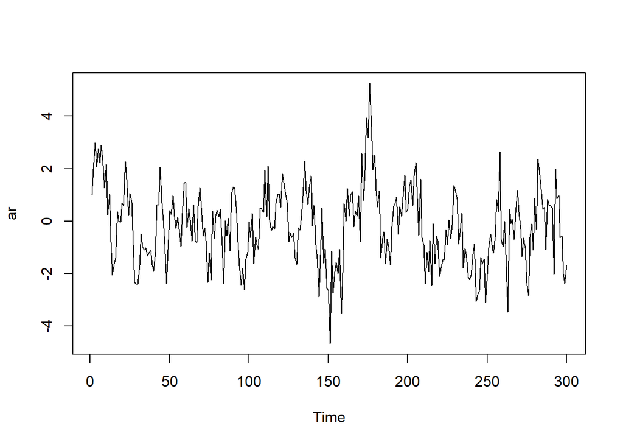

```r
ts.plot(ar)
```

Berdasarkan plot time series tersebut terlihat bahwa data cenderung stasioner pada rataan

### Plot ACF

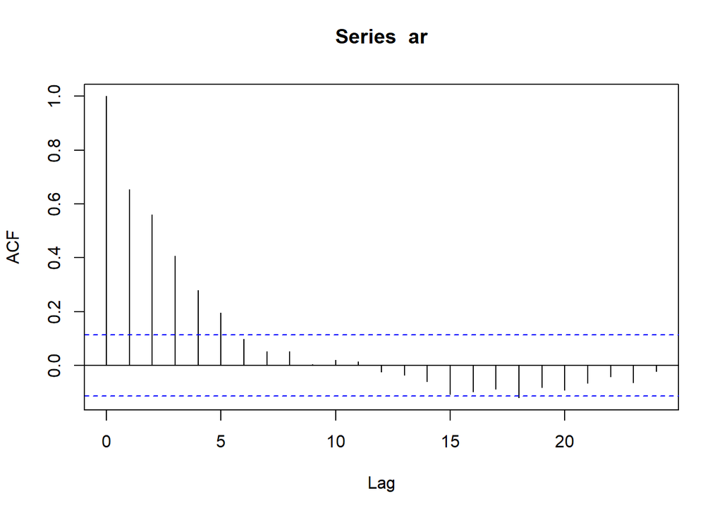

```r
acf(ar)
```

Berdasarkan plot ACF tersebut terlihat bahwa plot ACF cenderung *tails off* dan cenderung membentuk pola grafik sinus

### Plot PACF

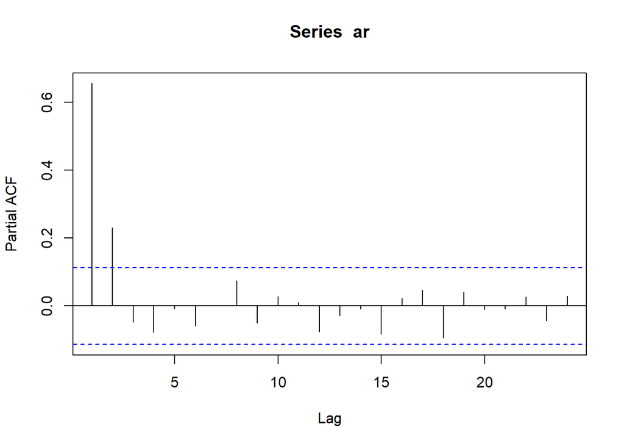

```r
pacf(ar)
```

### Plot EACF

```r
TSA::eacf(ar)
```

```
## AR/MA
##   0 1 2 3 4 5 6 7 8 9 10 11 12 13
## 0 x x x x x o o o o o o  o  o  o
## 1 x x o o o o o o o o o  o  o  o
## 2 x x o o o o o o o o o  o  o  o
## 3 x x o o o o o o o o o  o  o  o
## 4 o x o x o o o o o o o  o  o  o
## 5 x x o x o o o o o o o  o  o  o
## 6 o x x x x o o o o o o  o  o  o
## 7 o x x x x o o o o o o  o  o  o
```

### Scatterplot Antar Lag

#### Korelasi antara $Y_t$ dengan $Y_{t-1}$

```r
#Yt
yt_ar1 <- ar[-1]
yt_ar1
```

```
##   [1]  2.0000000000  2.9751633696  2.0749018065  2.7750097236  2.2180113566
##   [6]  2.8935141789  2.1270390330  1.2768395791  2.1689718684  0.2462598784
##  [11]  1.0187952211 -0.8023349463 -2.0534355833 -1.6270401901 -1.4181541123
##  [16]  0.3619464195 -0.0019943670 -0.0430467096  0.6803030017  0.5940848299
##  [21]  2.2692663171  1.6108525434  0.2138694086  1.0492893403  0.7167730812
##  [26] -0.8910724453 -2.3292254072 -2.3997849529 -2.3938812737 -1.6851082975
##  [31] -0.4735330278 -0.9572796691 -1.0998579504 -1.0146108718 -1.3330186313
##  [36] -1.2022987955 -1.1092906695 -1.6578804931 -1.8977691329 -1.1801203200
##  [41]  0.6204195404  0.6406805823  2.0589036930  0.6889378038  0.0301482399
##  [46] -0.8704773211 -2.3670245392 -1.0804604446  0.3947185365  0.2543963686
##  [51]  0.9616669605  0.1826943426 -0.2625101956  0.1396457657 -0.2805073785
##  [56] -0.9528006689  0.2940085459  1.4401353703  1.4785450357 -0.2342745592
##  [61]  0.4768434712  0.0437597178 -0.7716737805  0.6359809117 -0.7568693828
##  [66] -0.8251330133  0.5864251014  1.2720105101  0.5138475126 -0.5754762910
##  [71] -0.2464156282 -0.7550004167 -2.3344570229 -1.2110721135 -2.2498026489
```

[output cut: 45 more lines]

```r
#Yt-1
yt_1_ar <- ar[-300]
yt_1_ar
```

```
##   [1]  1.0000000000  2.0000000000  2.9751633696  2.0749018065  2.7750097236
##   [6]  2.2180113566  2.8935141789  2.1270390330  1.2768395791  2.1689718684
##  [11]  0.2462598784  1.0187952211 -0.8023349463 -2.0534355833 -1.6270401901
##  [16] -1.4181541123  0.3619464195 -0.0019943670 -0.0430467096  0.6803030017
##  [21]  0.5940848299  2.2692663171  1.6108525434  0.2138694086  1.0492893403
##  [26]  0.7167730812 -0.8910724453 -2.3292254072 -2.3997849529 -2.3938812737
##  [31] -1.6851082975 -0.4735330278 -0.9572796691 -1.0998579504 -1.0146108718
##  [36] -1.3330186313 -1.2022987955 -1.1092906695 -1.6578804931 -1.8977691329
##  [41] -1.1801203200  0.6204195404  0.6406805823  2.0589036930  0.6889378038
##  [46]  0.0301482399 -0.8704773211 -2.3670245392 -1.0804604446  0.3947185365
##  [51]  0.2543963686  0.9616669605  0.1826943426 -0.2625101956  0.1396457657
##  [56] -0.2805073785 -0.9528006689  0.2940085459  1.4401353703  1.4785450357
##  [61] -0.2342745592  0.4768434712  0.0437597178 -0.7716737805  0.6359809117
##  [66] -0.7568693828 -0.8251330133  0.5864251014  1.2720105101  0.5138475126
##  [71] -0.5754762910 -0.2464156282 -0.7550004167 -2.3344570229 -1.2110721135
```

[output cut: 45 more lines]

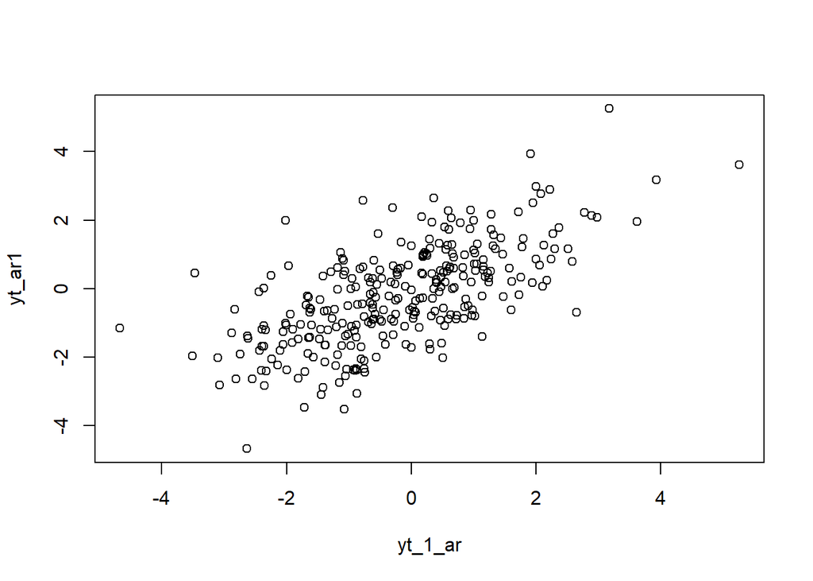

```r
plot(y=yt_ar1,x=yt_1_ar)
```

Berdasarkan scatterplot tersebut, terlihat bahwa terdapat hubungan positif antara $Y_t$ dengan $Y_{t-1}$. Hal ini sesuai dengan teori yang ada

```r
cor(yt_ar1,yt_1_ar)
```

```
## [1] 0.656812
```

#### Korelasi antara $Y_t$ dengan $Y_{t-2}$

```r
#Yt
yt_ar2 <- ar[c(-1,-2)]
yt_ar2
```

```
##   [1]  2.9751633696  2.0749018065  2.7750097236  2.2180113566  2.8935141789
##   [6]  2.1270390330  1.2768395791  2.1689718684  0.2462598784  1.0187952211
##  [11] -0.8023349463 -2.0534355833 -1.6270401901 -1.4181541123  0.3619464195
##  [16] -0.0019943670 -0.0430467096  0.6803030017  0.5940848299  2.2692663171
##  [21]  1.6108525434  0.2138694086  1.0492893403  0.7167730812 -0.8910724453
##  [26] -2.3292254072 -2.3997849529 -2.3938812737 -1.6851082975 -0.4735330278
##  [31] -0.9572796691 -1.0998579504 -1.0146108718 -1.3330186313 -1.2022987955
##  [36] -1.1092906695 -1.6578804931 -1.8977691329 -1.1801203200  0.6204195404
##  [41]  0.6406805823  2.0589036930  0.6889378038  0.0301482399 -0.8704773211
##  [46] -2.3670245392 -1.0804604446  0.3947185365  0.2543963686  0.9616669605
##  [51]  0.1826943426 -0.2625101956  0.1396457657 -0.2805073785 -0.9528006689
##  [56]  0.2940085459  1.4401353703  1.4785450357 -0.2342745592  0.4768434712
##  [61]  0.0437597178 -0.7716737805  0.6359809117 -0.7568693828 -0.8251330133
##  [66]  0.5864251014  1.2720105101  0.5138475126 -0.5754762910 -0.2464156282
##  [71] -0.7550004167 -2.3344570229 -1.2110721135 -2.2498026489  0.3783111654
```

[output cut: 45 more lines]

```r
#Yt-2
yt_2_ar <- ar[c(-299,-300)]
yt_2_ar
```

```
##   [1]  1.0000000000  2.0000000000  2.9751633696  2.0749018065  2.7750097236
##   [6]  2.2180113566  2.8935141789  2.1270390330  1.2768395791  2.1689718684
##  [11]  0.2462598784  1.0187952211 -0.8023349463 -2.0534355833 -1.6270401901
##  [16] -1.4181541123  0.3619464195 -0.0019943670 -0.0430467096  0.6803030017
##  [21]  0.5940848299  2.2692663171  1.6108525434  0.2138694086  1.0492893403
##  [26]  0.7167730812 -0.8910724453 -2.3292254072 -2.3997849529 -2.3938812737
##  [31] -1.6851082975 -0.4735330278 -0.9572796691 -1.0998579504 -1.0146108718
##  [36] -1.3330186313 -1.2022987955 -1.1092906695 -1.6578804931 -1.8977691329
##  [41] -1.1801203200  0.6204195404  0.6406805823  2.0589036930  0.6889378038
##  [46]  0.0301482399 -0.8704773211 -2.3670245392 -1.0804604446  0.3947185365
##  [51]  0.2543963686  0.9616669605  0.1826943426 -0.2625101956  0.1396457657
##  [56] -0.2805073785 -0.9528006689  0.2940085459  1.4401353703  1.4785450357
##  [61] -0.2342745592  0.4768434712  0.0437597178 -0.7716737805  0.6359809117
##  [66] -0.7568693828 -0.8251330133  0.5864251014  1.2720105101  0.5138475126
##  [71] -0.5754762910 -0.2464156282 -0.7550004167 -2.3344570229 -1.2110721135
```

[output cut: 45 more lines]

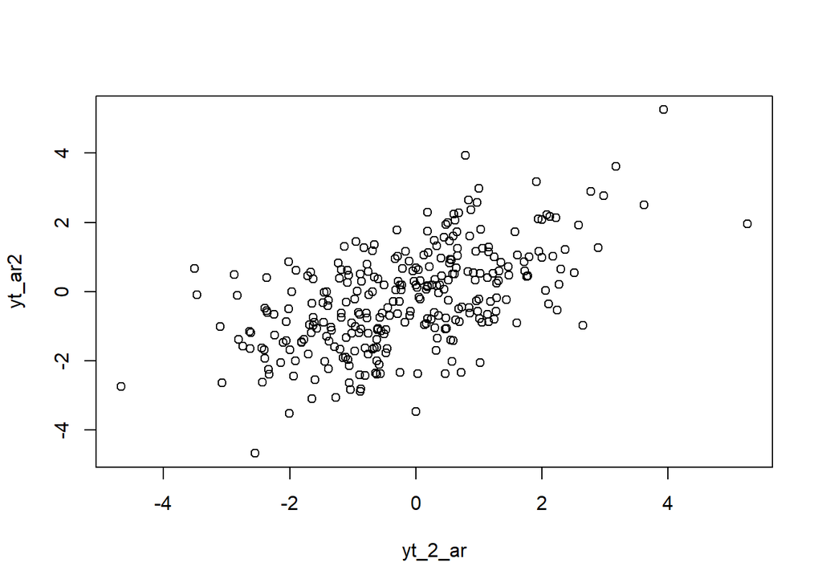

```r
plot(y=yt_ar2,x=yt_2_ar)
```

Berdasarkan scatterplot tersebut, terlihat bahwa terdapat hubungan positif antara $Y_t$ dengan $Y_{t-2}$. Hal ini sesuai dengan teori yang ada

```r
cor(yt_ar2,yt_2_ar)
```

```
## [1] 0.5663677
```

#### Korelasi antara $Y_t$ dengan $Y_{t-3}$

```r
#Yt
yt_ar3 <- ar[c(-1,-2,-3)]
yt_ar3
```

```
##   [1]  2.0749018065  2.7750097236  2.2180113566  2.8935141789  2.1270390330
##   [6]  1.2768395791  2.1689718684  0.2462598784  1.0187952211 -0.8023349463
##  [11] -2.0534355833 -1.6270401901 -1.4181541123  0.3619464195 -0.0019943670
##  [16] -0.0430467096  0.6803030017  0.5940848299  2.2692663171  1.6108525434
##  [21]  0.2138694086  1.0492893403  0.7167730812 -0.8910724453 -2.3292254072
##  [26] -2.3997849529 -2.3938812737 -1.6851082975 -0.4735330278 -0.9572796691
##  [31] -1.0998579504 -1.0146108718 -1.3330186313 -1.2022987955 -1.1092906695
##  [36] -1.6578804931 -1.8977691329 -1.1801203200  0.6204195404  0.6406805823
##  [41]  2.0589036930  0.6889378038  0.0301482399 -0.8704773211 -2.3670245392
##  [46] -1.0804604446  0.3947185365  0.2543963686  0.9616669605  0.1826943426
##  [51] -0.2625101956  0.1396457657 -0.2805073785 -0.9528006689  0.2940085459
##  [56]  1.4401353703  1.4785450357 -0.2342745592  0.4768434712  0.0437597178
##  [61] -0.7716737805  0.6359809117 -0.7568693828 -0.8251330133  0.5864251014
##  [66]  1.2720105101  0.5138475126 -0.5754762910 -0.2464156282 -0.7550004167
##  [71] -2.3344570229 -1.2110721135 -2.2498026489  0.3783111654 -0.6595034737
```

[output cut: 45 more lines]

```r
#Yt-1
yt_3_ar <- ar[c(-298,-299,-300)]
yt_3_ar
```

```
##   [1]  1.0000000000  2.0000000000  2.9751633696  2.0749018065  2.7750097236
##   [6]  2.2180113566  2.8935141789  2.1270390330  1.2768395791  2.1689718684
##  [11]  0.2462598784  1.0187952211 -0.8023349463 -2.0534355833 -1.6270401901
##  [16] -1.4181541123  0.3619464195 -0.0019943670 -0.0430467096  0.6803030017
##  [21]  0.5940848299  2.2692663171  1.6108525434  0.2138694086  1.0492893403
##  [26]  0.7167730812 -0.8910724453 -2.3292254072 -2.3997849529 -2.3938812737
##  [31] -1.6851082975 -0.4735330278 -0.9572796691 -1.0998579504 -1.0146108718
##  [36] -1.3330186313 -1.2022987955 -1.1092906695 -1.6578804931 -1.8977691329
##  [41] -1.1801203200  0.6204195404  0.6406805823  2.0589036930  0.6889378038
##  [46]  0.0301482399 -0.8704773211 -2.3670245392 -1.0804604446  0.3947185365
##  [51]  0.2543963686  0.9616669605  0.1826943426 -0.2625101956  0.1396457657
##  [56] -0.2805073785 -0.9528006689  0.2940085459  1.4401353703  1.4785450357
##  [61] -0.2342745592  0.4768434712  0.0437597178 -0.7716737805  0.6359809117
##  [66] -0.7568693828 -0.8251330133  0.5864251014  1.2720105101  0.5138475126
##  [71] -0.5754762910 -0.2464156282 -0.7550004167 -2.3344570229 -1.2110721135
```

[output cut: 45 more lines]

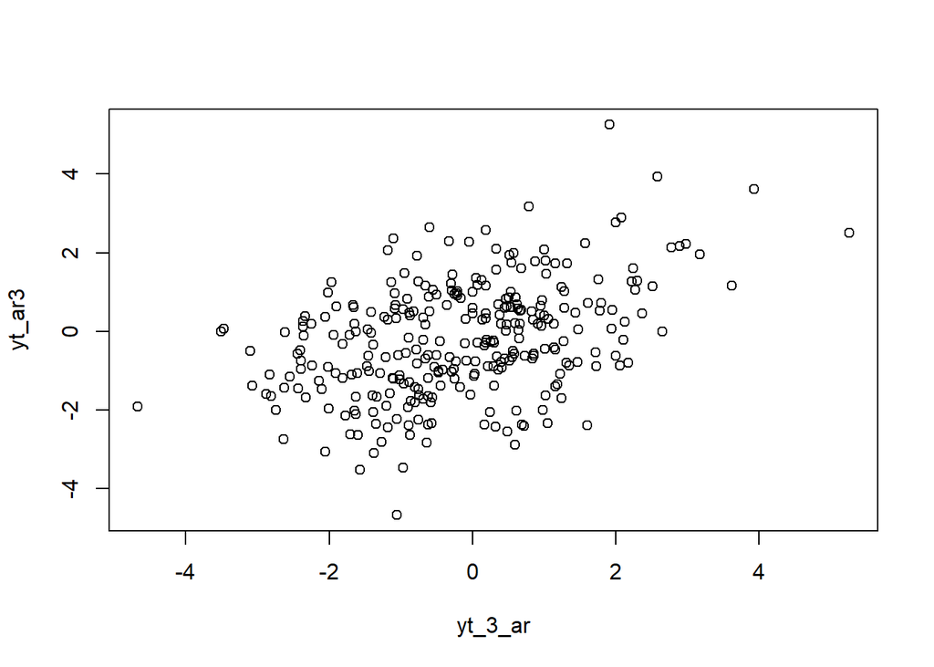

```r
plot(y=yt_ar3,x=yt_3_ar)
```

Berdasarkan scatterplot tersebut, terlihat bahwa terdapat hubungan positif antara $Y_t$ dengan $Y_{t-3}$. Hal ini sesuai dengan teori yang ada

```r
cor(yt_ar3,yt_3_ar)
```

```
## [1] 0.4164658
```

## Fungsi pembangkitan ARMA

Bentuk umum data berpola ARMA.

$$y_{t} = c + \sum_{i=1}^p \phi_{i}y_{t-i}
+ \sum_{j=1}^q e_{t-j}+ e_{t}$$

Komponen $c$ dan $e_{t}$ cukup mudah untuk dibuat dan dicari. Bagaimana untuk komponen AR dan MA? Bayangkan ada koefisien dan data sebagai berikut:

$$\begin{aligned}
\begin{bmatrix}
\phi_1 \ \phi_2
\end{bmatrix}&=
\begin{bmatrix}
0.5 \ 0.2
\end{bmatrix}
\\
\begin{bmatrix}
y_{t-1} \ y_{t-2}
\end{bmatrix}&=
\begin{bmatrix}
1 \ 2
\end{bmatrix}
\end{aligned}$$

Maka dari itu,

$$\begin{aligned}
\begin{bmatrix}
\phi_1 \ \phi_2 \
\end{bmatrix}
\begin{bmatrix}
y_{t-1} \\ y_{t-2}\end{bmatrix} &= \phi_1 \ y_{t-1}+\phi_2 \
y_{t-2}
\\
\begin{bmatrix}
0.5 \ 0.2
\end{bmatrix}
\begin{bmatrix}
1 \\ 2
\end{bmatrix} & = 0.5 \cdot1+0.2 \cdot 2\
&=0.5+0.4 = 0.9
\end{aligned}$$

Jika koefisien dan *white noise*/nilai deret waktu sebelumnya dapat diekstrak dalam bentuk vektor, dapat dilakukan perkalian matriks untuk mencari nilai bagian AR dan MA:

```r
set.seed(013)
coefs <- c(0.5, 0.2)
e <- c(1, 2)

coefs %*% e
```

```
##      [,1]
## [1,]  0.9
```

Atau, dapat dilakukan perkalian *elementwise* yang dijumlahkan:

```r
coefs * e
```

```
## [1] 0.5 0.4
```

```r
sum(coefs * e)
```

```
## [1] 0.9
```

Dari prinsip ini, dapat dibuat fungsi umum untuk membangkitkan data ARMA. Input dari fungsi adalah jumlah data yang hendak dibangkitkan, koefisien MA, dan koefisien AR

```r
arma.sim <- function(n, macoef, arcoef){
  manum <- length(macoef)
  arnum <- length(arcoef)
  stopifnot(manum < n & arnum < n)

  wn <- rnorm(n, sd = 1)
  init <- max(manum, arnum)

  arma <- wn[1:init]
  for(i in {init+1}:n){
   mastart <- i - manum
   maend <- i-1
   arstart <- i - arnum
   arend <- i-1
   arma[i] <- sum(arcoef * arma[arstart:arend]) + sum(macoef * wn[mastart:maend])  + wn[i]
   }
  return(arma)
}
```

Terlihat bahwa komponen $\sum_{i=1}^q y_{t-1}$ disimulasikan melalui `sum(arcoef * arma[arstart:arend])`. Jadi, koefisien dikalikan dengan data $y$ dari $t-q$ di mana q adalah jumlah koefisien AR, sampai data $t-1$. Lalu komponen $\sum_{j=1}^q e_{t-j}$ disimulasikan melalui `sum(macoef * wn[mastart:maend])`. Koefisien dikalikan dengan *white noise* $e$ dari $t-p$, p jumlah koefisien MA, sampai $t-1$.

```r
arma22 <- arma.sim(300, c(0.5, 0.2), c(0.4,0.6))

arma22 |> arima(c(2,0,2))
```

```
##
## Call:
## arima(x = arma22, order = c(2, 0, 2))
##
## Coefficients:
```

```
##          ar1     ar2     ma1     ma2  intercept
##       0.2318  0.7671  0.5029  0.0632   -14.2635
## s.e.     NaN     NaN     NaN     NaN    30.4599
##
## sigma^2 estimated as 1.351:  log likelihood = -474.14,  aic = 960.27
```

```r
set.seed(013)
n = length(wn)
phi1 = 0.5
phi2 = 0.2
theta1 = 0.4
theta2 = 0.6

y.arma=c(1:n)
for (i in 4:n){y.arma[i] = phi1*y.arma[i-1] + phi2*y.arma[i-2] + theta1*wn[i-1]+theta2*wn[i-2]+wn[i]}
```

Pembangkitan ARMA(p,q) juga dapat dilakukan dengan fungsi `arima.sim` sebagai berikut.

```r
arma22 <- arima.sim(list(order=c(2,0,2), ar = c(0.5,0.2), ma = c(0.4,0.6)), n=300)
arma22
```

```
## Time Series:
## Start = 1
## End = 300
## Frequency = 1
##   [1] -2.259304616 -3.868950002 -4.753489025 -4.084177325 -2.585159589
##   [6] -2.158714207 -1.767618705 -2.029477658 -2.399201467 -2.344595790
##  [11] -2.390267619 -2.823163768 -3.226638848 -2.934065373 -0.990373242
##  [16]  0.180712798  2.687379311  1.896870779  1.541037484 -0.445076760
##  [21] -2.697142851 -2.549569100 -1.457689854 -0.235999717  1.300251115
##  [26]  0.719994744  0.387564513  0.144255850 -0.382157052 -0.981217581
##  [31] -0.255417231  0.986057562  2.231003682  1.221224198  1.270260303
##  [36]  0.093932092 -0.468064023  0.353567068 -0.965481410 -0.746292314
##  [41] -0.197749805  1.011500688  1.374506736  0.393268988 -0.168297661
##  [46] -1.198852461 -2.784306581 -2.597855183 -4.134905716 -1.248253169
##  [51] -1.858060602  0.151535227  0.092191609  0.445916131  0.778652417
```

[output cut: 49 more lines]

## Karakteristik ARMA(2,2)

### Plot Time Series

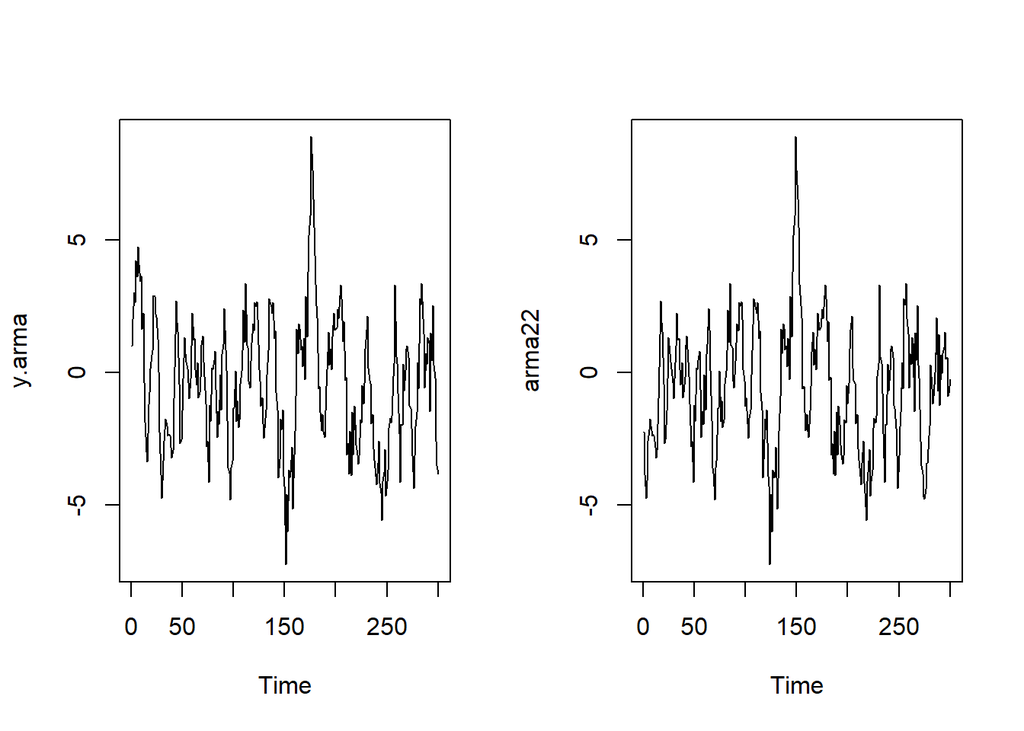

```r
par(mfrow = c(1, 2))
ts.plot(y.arma)
ts.plot(arma22)
```

```r
par(mfrow = c(1, 1))
```

Berdasarkan plot time series tersebut, terlihat bahwa model ARMA(2,2) cenderung stasioner dalam rataan

### Plot ACF

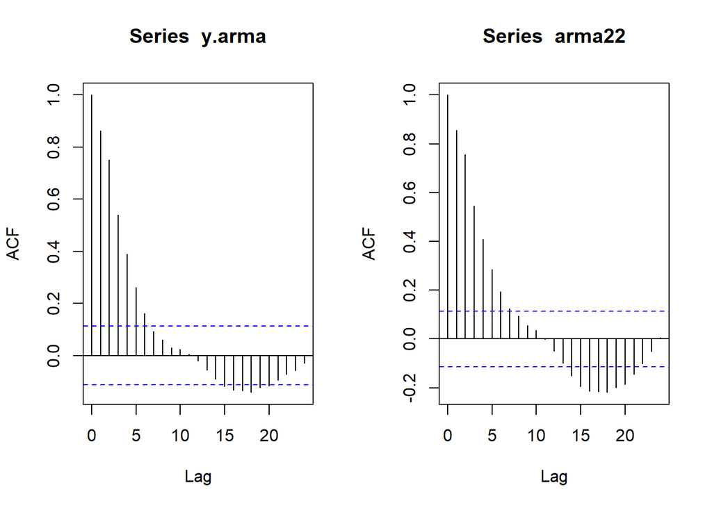

```r
par(mfrow = c(1, 2))
acf(y.arma)
acf(arma22)
```

```r
par(mfrow = c(1, 1))
```

Berdasarkan plot ACF tersebut, terlihat bahwa model ARMA(2,2) hasil simulasi memiliki plot ACF yang *tails off*, sesuai dengan teori yang ada

### Plot PACF

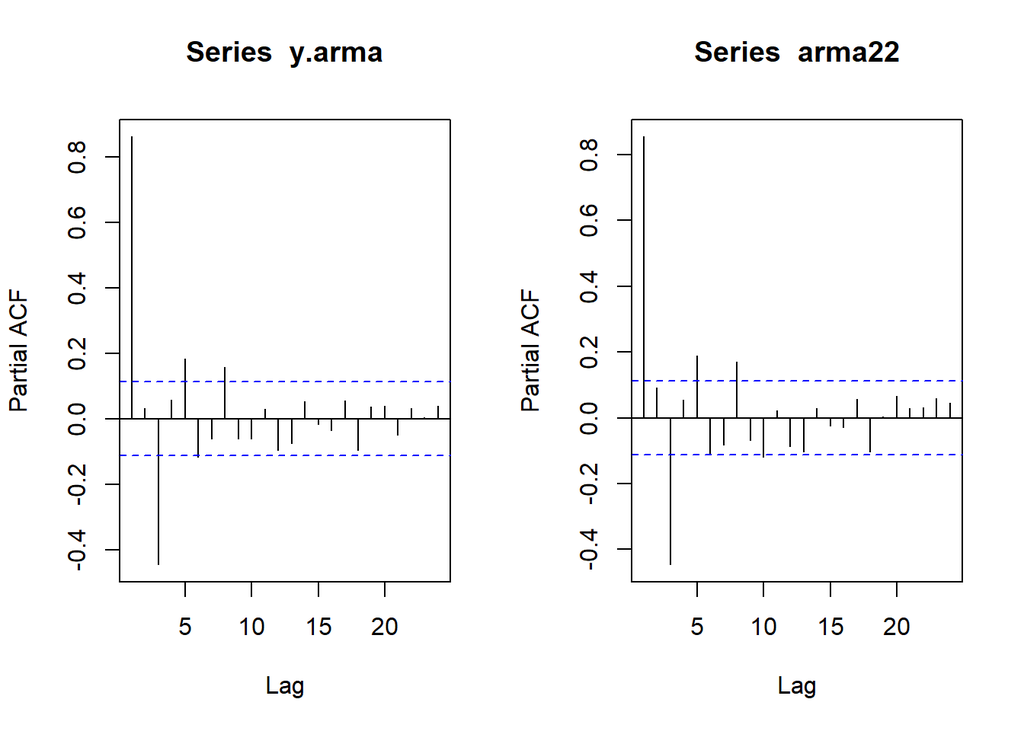

```r
par(mfrow = c(1, 2))
pacf(y.arma)
pacf(arma22)
```

```r
par(mfrow = c(1, 1))
```

### Plot EACF

```r
TSA::eacf(y.arma)
```

```
## AR/MA
##   0 1 2 3 4 5 6 7 8 9 10 11 12 13
## 0 x x x x x x o o o o o  o  o  o
## 1 o x o o o o o o o o o  o  o  o
## 2 o x o o o o o o o o o  o  o  o
## 3 o x x x o o o o o o o  o  o  o
## 4 x x o x o o o o o o o  o  o  o
## 5 x x o x o o o o o o o  o  o  o
## 6 x x x o o o o o o o o  o  o  o
## 7 x x x o x o o x o o o  o  o  o
```

```r
TSA::eacf(arma22)
```

```
## AR/MA
##   0 1 2 3 4 5 6 7 8 9 10 11 12 13
## 0 x x x x x x x o o o o  o  o  x
## 1 o x o o o o o o o o o  o  o  o
## 2 x x x o o o o o o o o  o  o  o
## 3 o x x o o o o o o o o  o  o  o
## 4 x x x o x o o o o o o  o  o  o
## 5 x x o o o x o o o o o  o  o  o
## 6 x x o o o o o o o o o  o  o  o
## 7 x x o o x o o o o o o  o  o  o
```

### Scatterplot Antar Lag

#### Korelasi antara $Y_t$ dengan $Y_{t-1}$

```r
#Yt
yt_arma1 <- arma22[-1]
yt_arma1
```

```
##   [1] -3.868950002 -4.753489025 -4.084177325 -2.585159589 -2.158714207
##   [6] -1.767618705 -2.029477658 -2.399201467 -2.344595790 -2.390267619
##  [11] -2.823163768 -3.226638848 -2.934065373 -0.990373242  0.180712798
##  [16]  2.687379311  1.896870779  1.541037484 -0.445076760 -2.697142851
##  [21] -2.549569100 -1.457689854 -0.235999717  1.300251115  0.719994744
##  [26]  0.387564513  0.144255850 -0.382157052 -0.981217581 -0.255417231
##  [31]  0.986057562  2.231003682  1.221224198  1.270260303  0.093932092
##  [36] -0.468064023  0.353567068 -0.965481410 -0.746292314 -0.197749805
##  [41]  1.011500688  1.374506736  0.393268988 -0.168297661 -1.198852461
##  [46] -2.784306581 -2.597855183 -4.134905716 -1.248253169 -1.858060602
##  [51]  0.151535227  0.092191609  0.445916131  0.778652417 -0.642477284
##  [56] -2.461617598 -1.486154229 -1.960604279 -0.084904099 -1.409826968
##  [61]  0.682626895  1.054603352  2.406622578  1.603126257  0.070844820
##  [66] -1.833068389 -3.592485676 -3.803468682 -4.797568412 -3.589160878
##  [71] -3.336592432 -1.374303298 -1.340654643  0.032621449 -1.857482159
```

[output cut: 45 more lines]

```r
#Yt-1
yt_1_arma <- arma22[-300]
yt_1_arma
```

```
##   [1] -2.259304616 -3.868950002 -4.753489025 -4.084177325 -2.585159589
##   [6] -2.158714207 -1.767618705 -2.029477658 -2.399201467 -2.344595790
##  [11] -2.390267619 -2.823163768 -3.226638848 -2.934065373 -0.990373242
##  [16]  0.180712798  2.687379311  1.896870779  1.541037484 -0.445076760
##  [21] -2.697142851 -2.549569100 -1.457689854 -0.235999717  1.300251115
##  [26]  0.719994744  0.387564513  0.144255850 -0.382157052 -0.981217581
##  [31] -0.255417231  0.986057562  2.231003682  1.221224198  1.270260303
##  [36]  0.093932092 -0.468064023  0.353567068 -0.965481410 -0.746292314
##  [41] -0.197749805  1.011500688  1.374506736  0.393268988 -0.168297661
##  [46] -1.198852461 -2.784306581 -2.597855183 -4.134905716 -1.248253169
##  [51] -1.858060602  0.151535227  0.092191609  0.445916131  0.778652417
##  [56] -0.642477284 -2.461617598 -1.486154229 -1.960604279 -0.084904099
##  [61] -1.409826968  0.682626895  1.054603352  2.406622578  1.603126257
##  [66]  0.070844820 -1.833068389 -3.592485676 -3.803468682 -4.797568412
##  [71] -3.589160878 -3.336592432 -1.374303298 -1.340654643  0.032621449
```

[output cut: 45 more lines]

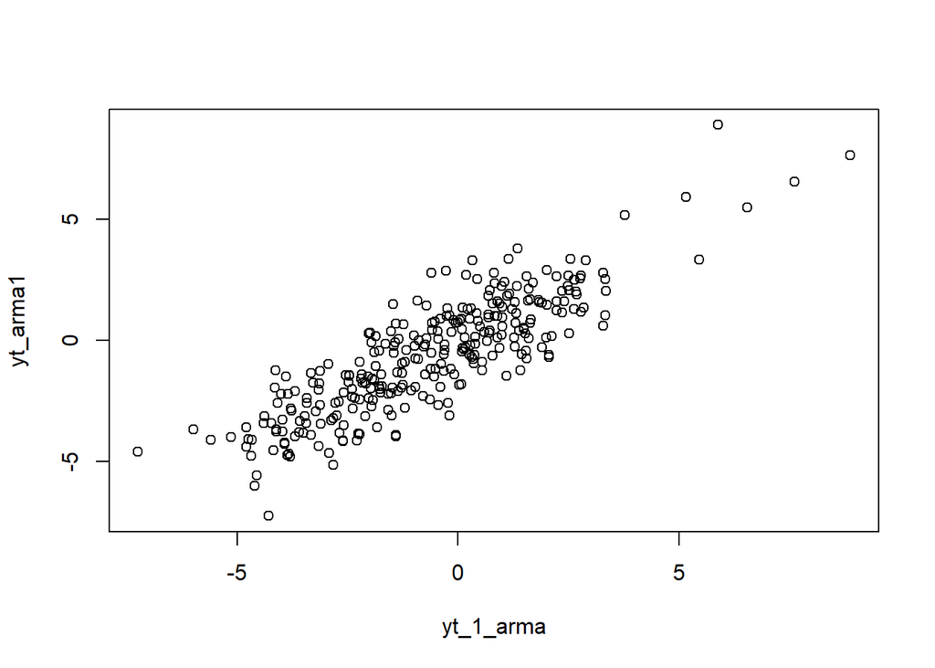

```r
plot(y=yt_arma1,x=yt_1_arma)
```

Berdasarkan scatterplot tersebut, terlihat bahwa terdapat hubungan positif antara $Y_t$ dengan $Y_{t-1}$. Hal ini sesuai dengan teori yang ada

```r
cor(yt_arma1,yt_1_arma)
```

```
## [1] 0.8554634
```

#### Korelasi antara $Y_t$ dengan $Y_{t-2}$

```r
#Yt
yt_arma2 <- arma22[c(-1,-2)]
yt_arma2
```

```
##   [1] -4.753489025 -4.084177325 -2.585159589 -2.158714207 -1.767618705
##   [6] -2.029477658 -2.399201467 -2.344595790 -2.390267619 -2.823163768
##  [11] -3.226638848 -2.934065373 -0.990373242  0.180712798  2.687379311
##  [16]  1.896870779  1.541037484 -0.445076760 -2.697142851 -2.549569100
##  [21] -1.457689854 -0.235999717  1.300251115  0.719994744  0.387564513
##  [26]  0.144255850 -0.382157052 -0.981217581 -0.255417231  0.986057562
##  [31]  2.231003682  1.221224198  1.270260303  0.093932092 -0.468064023
##  [36]  0.353567068 -0.965481410 -0.746292314 -0.197749805  1.011500688
##  [41]  1.374506736  0.393268988 -0.168297661 -1.198852461 -2.784306581
##  [46] -2.597855183 -4.134905716 -1.248253169 -1.858060602  0.151535227
##  [51]  0.092191609  0.445916131  0.778652417 -0.642477284 -2.461617598
##  [56] -1.486154229 -1.960604279 -0.084904099 -1.409826968  0.682626895
##  [61]  1.054603352  2.406622578  1.603126257  0.070844820 -1.833068389
##  [66] -3.592485676 -3.803468682 -4.797568412 -3.589160878 -3.336592432
##  [71] -1.374303298 -1.340654643  0.032621449 -1.857482159 -1.064463577
```

[output cut: 45 more lines]

```r
#Yt-1
yt_2_arma <- arma22[c(-299,-300)]
yt_2_arma
```

```
##   [1] -2.259304616 -3.868950002 -4.753489025 -4.084177325 -2.585159589
##   [6] -2.158714207 -1.767618705 -2.029477658 -2.399201467 -2.344595790
##  [11] -2.390267619 -2.823163768 -3.226638848 -2.934065373 -0.990373242
##  [16]  0.180712798  2.687379311  1.896870779  1.541037484 -0.445076760
##  [21] -2.697142851 -2.549569100 -1.457689854 -0.235999717  1.300251115
##  [26]  0.719994744  0.387564513  0.144255850 -0.382157052 -0.981217581
##  [31] -0.255417231  0.986057562  2.231003682  1.221224198  1.270260303
##  [36]  0.093932092 -0.468064023  0.353567068 -0.965481410 -0.746292314
##  [41] -0.197749805  1.011500688  1.374506736  0.393268988 -0.168297661
##  [46] -1.198852461 -2.784306581 -2.597855183 -4.134905716 -1.248253169
##  [51] -1.858060602  0.151535227  0.092191609  0.445916131  0.778652417
##  [56] -0.642477284 -2.461617598 -1.486154229 -1.960604279 -0.084904099
##  [61] -1.409826968  0.682626895  1.054603352  2.406622578  1.603126257
##  [66]  0.070844820 -1.833068389 -3.592485676 -3.803468682 -4.797568412
##  [71] -3.589160878 -3.336592432 -1.374303298 -1.340654643  0.032621449
```

[output cut: 45 more lines]

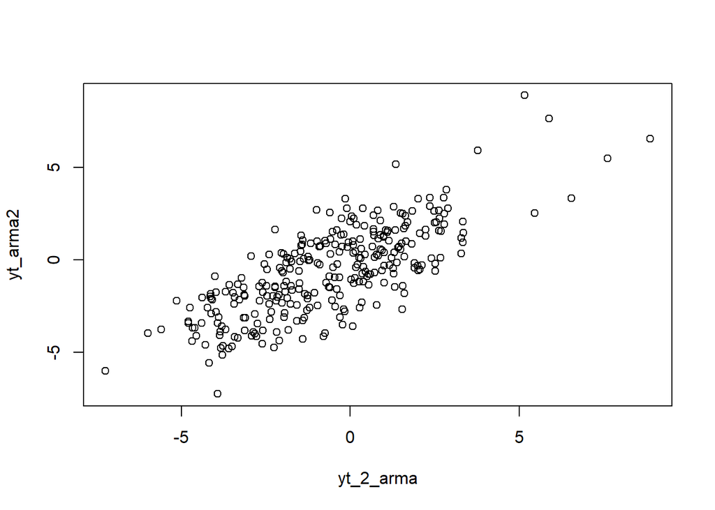

```r
plot(y=yt_arma2,x=yt_2_arma)
```

Berdasarkan scatterplot tersebut, terlihat bahwa terdapat hubungan positif antara $Y_t$ dengan $Y_{t-2}$. Hal ini sesuai dengan teori yang ada

```r
cor(yt_arma2,yt_2_arma)
```

```
## [1] 0.7585238
```

#### Korelasi antara $Y_t$ dengan $Y_{t-3}$

```r
#Yt
yt_arma3 <- arma22[c(-1,-2,-3)]
yt_arma3
```

```
##   [1] -4.084177325 -2.585159589 -2.158714207 -1.767618705 -2.029477658
##   [6] -2.399201467 -2.344595790 -2.390267619 -2.823163768 -3.226638848
##  [11] -2.934065373 -0.990373242  0.180712798  2.687379311  1.896870779
##  [16]  1.541037484 -0.445076760 -2.697142851 -2.549569100 -1.457689854
##  [21] -0.235999717  1.300251115  0.719994744  0.387564513  0.144255850
##  [26] -0.382157052 -0.981217581 -0.255417231  0.986057562  2.231003682
##  [31]  1.221224198  1.270260303  0.093932092 -0.468064023  0.353567068
##  [36] -0.965481410 -0.746292314 -0.197749805  1.011500688  1.374506736
##  [41]  0.393268988 -0.168297661 -1.198852461 -2.784306581 -2.597855183
##  [46] -4.134905716 -1.248253169 -1.858060602  0.151535227  0.092191609
##  [51]  0.445916131  0.778652417 -0.642477284 -2.461617598 -1.486154229
##  [56] -1.960604279 -0.084904099 -1.409826968  0.682626895  1.054603352
##  [61]  2.406622578  1.603126257  0.070844820 -1.833068389 -3.592485676
##  [66] -3.803468682 -4.797568412 -3.589160878 -3.336592432 -1.374303298
##  [71] -1.340654643  0.032621449 -1.857482159 -1.064463577 -2.088732545
```

[output cut: 45 more lines]

```r
#Yt-1
yt_3_arma <- arma22[c(-298,-299,-300)]
yt_3_arma
```

```
##   [1] -2.259304616 -3.868950002 -4.753489025 -4.084177325 -2.585159589
##   [6] -2.158714207 -1.767618705 -2.029477658 -2.399201467 -2.344595790
##  [11] -2.390267619 -2.823163768 -3.226638848 -2.934065373 -0.990373242
##  [16]  0.180712798  2.687379311  1.896870779  1.541037484 -0.445076760
##  [21] -2.697142851 -2.549569100 -1.457689854 -0.235999717  1.300251115
##  [26]  0.719994744  0.387564513  0.144255850 -0.382157052 -0.981217581
##  [31] -0.255417231  0.986057562  2.231003682  1.221224198  1.270260303
##  [36]  0.093932092 -0.468064023  0.353567068 -0.965481410 -0.746292314
##  [41] -0.197749805  1.011500688  1.374506736  0.393268988 -0.168297661
##  [46] -1.198852461 -2.784306581 -2.597855183 -4.134905716 -1.248253169
##  [51] -1.858060602  0.151535227  0.092191609  0.445916131  0.778652417
##  [56] -0.642477284 -2.461617598 -1.486154229 -1.960604279 -0.084904099
##  [61] -1.409826968  0.682626895  1.054603352  2.406622578  1.603126257
##  [66]  0.070844820 -1.833068389 -3.592485676 -3.803468682 -4.797568412
##  [71] -3.589160878 -3.336592432 -1.374303298 -1.340654643  0.032621449
```

[output cut: 45 more lines]

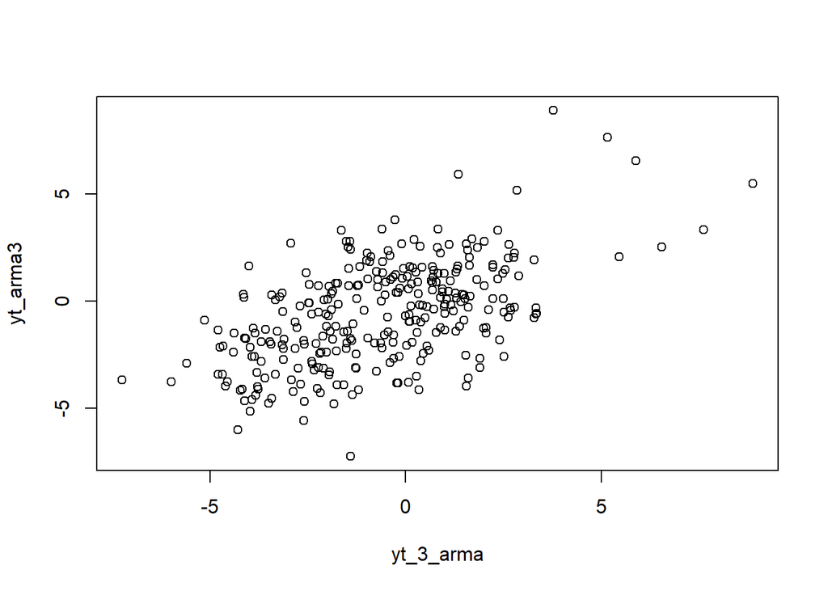

```r
plot(y=yt_arma3,x=yt_3_arma)
```

Berdasarkan scatterplot tersebut, terlihat bahwa terdapat hubungan positif antara $Y_t$ dengan $Y_{t-3}$. Hal ini sesuai dengan teori yang ada

```r
cor(yt_arma3,yt_3_arma)
```

```
## [1] 0.550968
```